# Analiza Danych: Laureaci Nagrody Nobla

Author

Daniel Terlecki

## Rozkład nagród

Liczba nagród i na ile laureatów była dzielona. Wszystkich nagród jest 579

| Dzielona na _ laureata(ów): | Ilość laureatów: | Liczba nagród: |
| --- | --- | --- |
| jednego | 344 | 344 |
| dwóch | 306 | 153 |
| trzech | 201 | 67 |
| czterech | 60 | 15 |

Zdecydowanoa większość nagród przyznawana była pojedynczym osobom, mniej niż połowa nagród była dzielona na kilka osób.

## Rozkład rozdania nagród

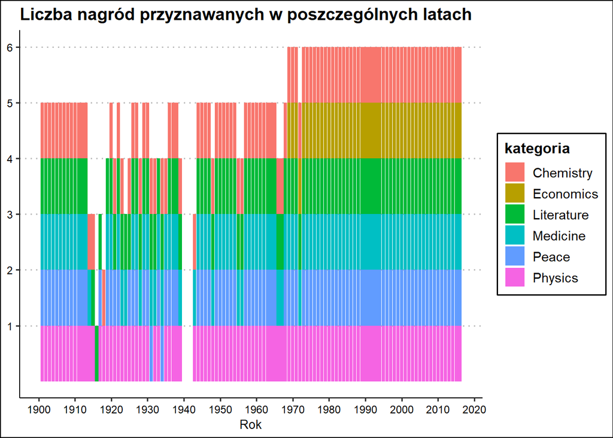

Wykres przedstawia ciągłość przyznawania nagród na przestrzeni lat. Wyraźnie widoczne są luki w przyznawaniu nagród podczas konfliktów światowych oraz rozwój zestawienia o nową kategorię (ekonomię) w późniejszym okresie.

## Liczba laureatów w danych kategoriach

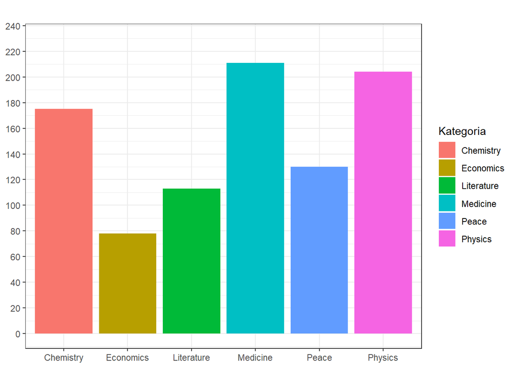

Precyzyjny wgląd na ilość nagród ze wszystkich kategorii.

## Laureaci z wieloma nagrodami

Lista laureatów z wieloma nagrodami

| Imię i nazwisko | nagrody |
| --- | --- |
| Comité international de la Croix Rouge (International Committee of the Red Cross) | 3 |
| Frederick Sanger | 2 |
| John Bardeen | 2 |
| Linus Carl Pauling | 2 |
| Marie Curie, née Sklodowska | 2 |
| Office of the United Nations High Commissioner for Refugees (UNHCR) | 2 |

Wygranie Nobla więcej niż raz to ogromna rzadkość, często udaje się to nie pojedynczym ludziom, ale instytucjom i organizacjom międzynarodowym.

## Wiek laureatów

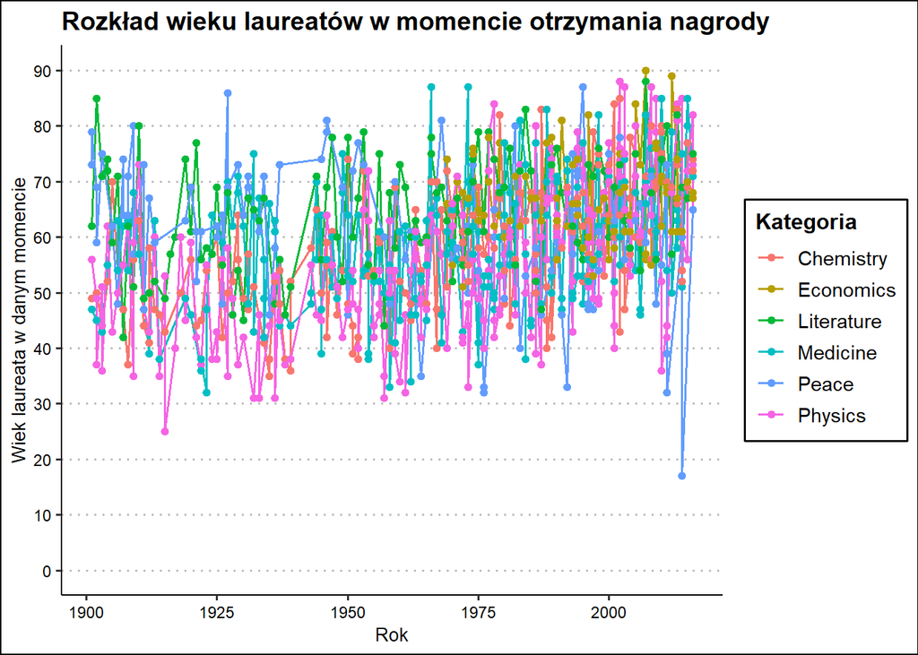

Wykres przedstawia rozkład wieku laureatów w momencie przyznania Nagrody Nobla. Dane wskazują na znaczną rozpiętość wiekową, od osób koło 20 roku życia do prawie 90 latków oraz wyraźne różnice w zależności od analizowanej kategorii.

## Ranking Krajów

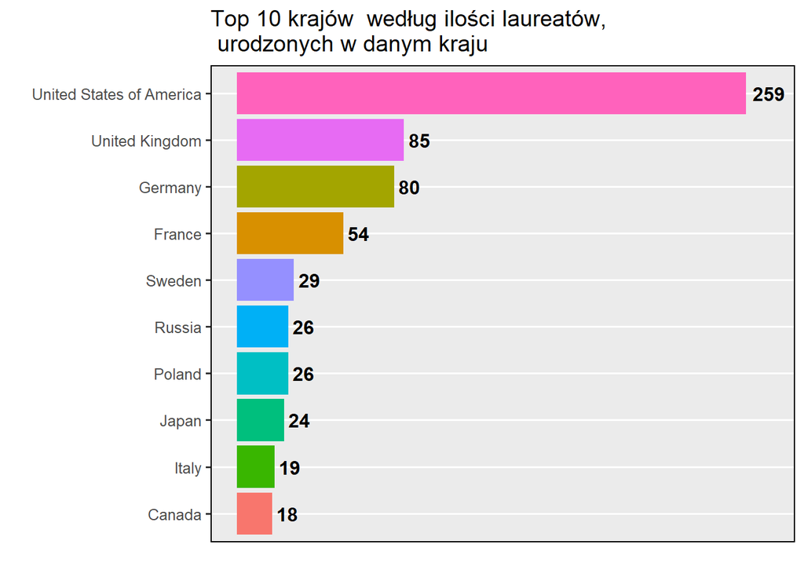

Stany Zjednoczone dominują pośród krajów. Drugi w rankingu ma tylko jedną trzecią nagród w porównaniu.

## 10 najstarszych oraz najmłodszych laureatów

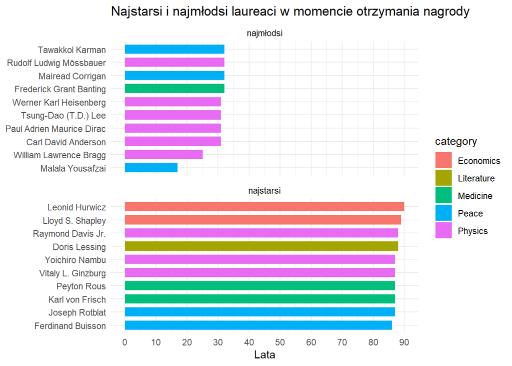

## Najdłużej żyjący laureaci(pośród zmarłych)

Najdłużej żyjący laureaci ze zmarłych

| Imię i nazwisko | żył __ lat(a) |
| --- | --- |
| Rita Levi-Montalcini | 103 |
| Ronald H. Coase | 102 |
| Charles Hard Townes | 99 |
| Maurice Allais | 99 |
| Tadeus Reichstein | 99 |
| Hans Albrecht Bethe | 98 |
| Renato Dulbecco | 97 |
| Earl (Bertrand Arthur William) Russell | 97 |
| George Hoyt Whipple | 97 |
| Joseph Rotblat | 96 |

Zestawienie ukazuje najdłużej żyjących laureatów, cała czołówka osiągnęła wiek powyżej 90, w tym są osoby stuletnie.

## Migranci pośród laureatów

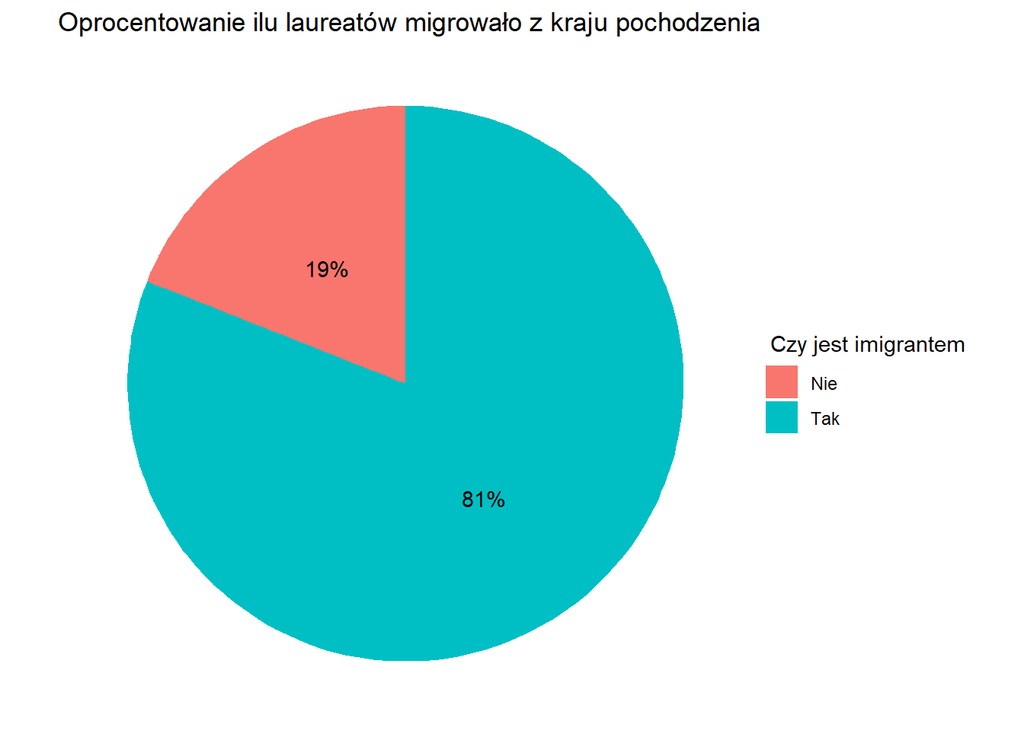

Większość laureatów zdobyła Nobla w innym kraju niż ten, w którym się urodziła. To pokazało, jak ogromną rolę w sukcesie naukowym gra międzynarodowa mobilność i wyjazd do lepszych ośrodków.